# Programming Assignment: Build a CNN for image recognition.

### Name: Qi Qu

## 0. You will do the following:

1. Read, complete, and run the code.
2. **Make substantial improvements** to maximize the accuracy.
3. Convert the .IPYNB file to .HTML file.
   - The HTML file must contain the code and the output after execution.
   - Missing **the output after execution** will not be graded.
4. Upload the .HTML file to your Google Drive, Dropbox, or Github repo. (If you submit the file to Google Drive or Dropbox, you must make the file "open-access". The delay caused by "deny of access" may result in late penalty.)
5. On Canvas, submit the Google Drive/Dropbox/Github link to the HTML file.

## Requirements:

1. You can use whatever CNN architecture, including VGG, Inception, and ResNet. However, you must build the networks layer by layer. You must NOT import the archetectures from `keras.applications`.
2. Make sure `BatchNormalization` is between a `Conv`/`Dense` layer and an `activation` layer.
3. If you want to regularize a `Conv`/`Dense` layer, you should place a `Dropout` layer **before** the `Conv`/`Dense` layer.
4. An accuracy above 70% is considered reasonable. An accuracy above 80% is considered good. Without data augmentation, achieving 80% accuracy is difficult.

## Google Colab

- If you do not have GPU, the training of a CNN can be slow. Google Colab is a good option.
- Keep in mind that you must download it as an IPYNB file and then use IPython Notebook to convert it to HTML.
- Also keep in mind that the IPYNB and HTML files must contain the outputs. (Otherwise, the instructor will not be able to know the correctness and performance.) Do the followings to keep the outputs.
- In Colab, go to `Runtime` --> `Change runtime type` --> Do NOT check `Omit code cell output when saving this notebook`. In this way, the downloaded IPYNB file contains the outputs.

## 1. Data preparation

### 1.1. Load data

```python
import numpy as np
import os
import pickle

# Load a single batch file
def load_batch(filepath):
    with open(filepath, 'rb') as f:
        dict = pickle.load(f, encoding='bytes')
        data = dict[b'data']
        labels = dict[b'labels']
        data = data.reshape(len(data), 3, 32, 32).transpose(0, 2, 3, 1)  # Convert to (N, 32, 32, 3)
        return data, labels

# Load test data
x_train = []
y_train = []

for i in range(1, 6):
    data_batch, labels_batch = load_batch(f'cifar-10-batches-py/data_batch_{i}')
    x_train.append(data_batch)
    y_train.extend(labels_batch)

x_train = np.concatenate(x_train)
y_train = np.array(y_train)

#Load test data
x_test, y_test = load_batch('cifar-10-batches-py/test_batch')
y_test = np.array(y_test)

print('x_train shape:', x_train.shape)
print('y_train shape:', y_train.shape)
print('x_test shape:', x_test.shape)
print('y_test shape:', y_test.shape)
print('Number of classes:', len(np.unique(y_train)))
```

```
x_train shape: (50000, 32, 32, 3)
y_train shape: (50000,)
x_test shape: (10000, 32, 32, 3)
y_test shape: (10000,)
Number of classes: 10
```

### 1.2. One-hot encode the labels

In the input, a label is a scalar in $\{0, 1, \cdots , 9\}$. One-hot encode transform such a scalar to a $10$-dim vector. E.g., a scalar `y_train[j]=3` is transformed to the vector `y_train_vec[j]=[0, 0, 0, 1, 0, 0, 0, 0, 0, 0]`.

1. Define a function `to_one_hot` that transforms an $n\times 1$ array to a $n\times 10$ matrix.
2. Apply the function to `y_train` and `y_test`.

```python
import numpy as np

# 1.Custom one-hot encoding function
def to_one_hot(y, num_classes=10):
    y = np.array(y)
    n = y.shape[0]
    one_hot = np.zeros((n, num_classes))
    one_hot[np.arange(n), y] = 1
    return one_hot

# 2.Apply to training and test sets
y_train_vec = to_one_hot(y_train, num_classes=10)
y_test_vec = to_one_hot(y_test, num_classes=10)

# 3. Print shapes and example
print("Shape of y_train_vec:", y_train_vec.shape)
print("Shape of y_test_vec:", y_test_vec.shape)

print([y_train[0]])
print(y_train_vec[0])
```

```
Shape of y_train_vec: (50000, 10)
Shape of y_test_vec: (10000, 10)
[6]
[0. 0. 0. 0. 0. 0. 1. 0. 0. 0.]
```

#### Remark: the outputs should be

- Shape of y_train_vec: (50000, 10)
- Shape of y_test_vec: (10000, 10)
- [6]
- [0. 0. 0. 0. 0. 0. 1. 0. 0. 0.]

### 1.3. Randomly partition the training set to training and validation sets

Randomly partition the 50K training samples to 2 sets:

- a training set containing 40K samples
- a validation set containing 10K samples

```python
# Set random seed for reproducibility
np.random.seed(42)

# Total number of samples
num_total = x_train.shape[0]

# Shuffle indices
indices = np.random.permutation(num_total)

# Split indices
train_indices = indices[:40000]
val_indices = indices[40000:]

# Split image data
x_tr = x_train[train_indices]
x_val = x_train[val_indices]

# Split corresponding labels
y_tr = y_train_vec[train_indices]
y_val = y_train_vec[val_indices]

# Print shapes for confirmation
print("x_tr shape:", x_tr.shape)
print("y_tr shape:", y_tr.shape)
print("x_val shape:", x_val.shape)
print("y_val shape:", y_val.shape)
```

```
x_tr shape: (40000, 32, 32, 3)
y_tr shape: (40000, 10)
x_val shape: (10000, 32, 32, 3)
y_val shape: (10000, 10)
```

## 2. Build a CNN and tune its hyper-parameters

1. Build a convolutional neural network model
2. Use the validation data to tune the hyper-parameters (e.g., network structure, and optimization algorithm)
   - Do NOT use test data for hyper-parameter tuning!!!
3. Try to achieve a validation accuracy as high as possible.

### Remark:

The following CNN is just an example. You are supposed to make **substantial improvements** such as:

- Add more layers.
- Use regularizations, e.g., dropout.
- Use batch normalization.

```python
import tensorflow as tf
from tensorflow.keras import layers, models

model = models.Sequential([
    # Conv Block 1
    layers.Conv2D(32, (3, 3), padding='same', activation='relu', input_shape=(32, 32, 3)),
    layers.BatchNormalization(),
    layers.Conv2D(32, (3, 3), padding='same', activation='relu'),
    layers.BatchNormalization(),
    layers.MaxPooling2D(pool_size=(2, 2)),
    layers.Dropout(0.25),

    # Conv Block 2
    layers.Conv2D(64, (3, 3), padding='same', activation='relu'),
    layers.BatchNormalization(),
    layers.Conv2D(64, (3, 3), padding='same', activation='relu'),
    layers.BatchNormalization(),
    layers.MaxPooling2D(pool_size=(2, 2)),
    layers.Dropout(0.25),

    # Conv Block 3
    layers.Conv2D(128, (3, 3), padding='same', activation='relu'),
    layers.BatchNormalization(),
    layers.Conv2D(128, (3, 3), padding='same', activation='relu'),
    layers.BatchNormalization(),
    layers.MaxPooling2D(pool_size=(2, 2)),
    layers.Dropout(0.25),

    # Fully Connected
    layers.Flatten(),
    layers.Dense(256, activation='relu'),
    layers.BatchNormalization(),
    layers.Dropout(0.5),
    layers.Dense(10, activation='softmax')
])
```

```python
model.compile(
    optimizer='adam',
    loss='categorical_crossentropy',
    metrics=['accuracy']
)
```

```python
history = model.fit(
    x_tr, y_tr,
    epochs=30,
    batch_size=64,
    validation_data=(x_val, y_val)
)
```

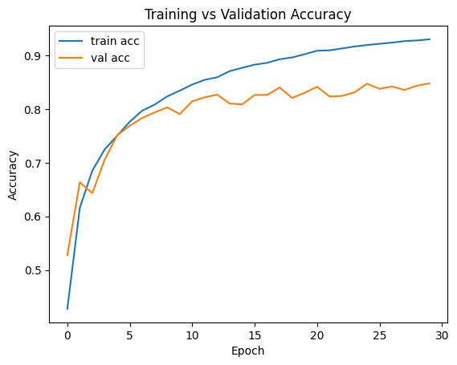

```python
import matplotlib.pyplot as plt

plt.plot(history.history['accuracy'], label='train acc')
plt.plot(history.history['val_accuracy'], label='val acc')
plt.xlabel('Epoch')
plt.ylabel('Accuracy')
plt.legend()
plt.title('Training vs Validation Accuracy')
plt.show()
```

## 3. Train (again) and evaluate the model

- To this end, you have found the "best" hyper-parameters.
- Now, fix the hyper-parameters and train the network on the entire training set (all the 50K training samples)
- Evaluate your model on the test set.

### 3.1. Train the model on the entire training set

Why? Previously, you used 40K samples for training; you wasted 10K samples for the sake of hyper-parameter tuning. Now you already know the hyper-parameters, so why not using all the 50K samples for training?

```python
# Merge training and validation sets
x_full = np.concatenate([x_tr, x_val], axis=0)
y_full = np.concatenate([y_tr, y_val], axis=0)
```

```python
# Re-initialize the model (same as during hyperparameter tuning)
model = models.Sequential([
    layers.Conv2D(32, (3, 3), padding='same', activation='relu', input_shape=(32, 32, 3)),
    layers.BatchNormalization(),
    layers.Conv2D(32, (3, 3), padding='same', activation='relu'),
    layers.BatchNormalization(),
    layers.MaxPooling2D(pool_size=(2, 2)),
    layers.Dropout(0.25),

    layers.Conv2D(64, (3, 3), padding='same', activation='relu'),
    layers.BatchNormalization(),
    layers.Conv2D(64, (3, 3), padding='same', activation='relu'),
    layers.BatchNormalization(),
    layers.MaxPooling2D(pool_size=(2, 2)),
    layers.Dropout(0.25),

    layers.Conv2D(128, (3, 3), padding='same', activation='relu'),
    layers.BatchNormalization(),
    layers.Conv2D(128, (3, 3), padding='same', activation='relu'),
    layers.BatchNormalization(),
    layers.MaxPooling2D(pool_size=(2, 2)),
    layers.Dropout(0.25),

    layers.Flatten(),
    layers.Dense(256, activation='relu'),
    layers.BatchNormalization(),
    layers.Dropout(0.5),
    layers.Dense(10, activation='softmax')
])

model.compile(
    optimizer='adam',
    loss='categorical_crossentropy',
    metrics=['accuracy']
)
```

```python
 model.fit(
    x_full, y_full,
    epochs=30,
    batch_size=64
)
```

```
<keras.src.callbacks.History at 0x31f747c70>
```

```python
test_loss, test_acc = model.evaluate(x_test, y_test_vec)
print("Test Accuracy:", test_acc)
```

```
Test Accuracy: 0.8446999788284302
```

### 3.2. Evaluate the model on the test set

Do NOT used the test set until now. Make sure that your model parameters and hyper-parameters are independent of the test set.

```python
from sklearn.metrics import classification_report, confusion_matrix
import numpy as np

# Predict labels (convert one-hot to integers)
y_pred = model.predict(x_test)
y_pred_classes = np.argmax(y_pred, axis=1)
y_true_classes = np.argmax(y_test_vec, axis=1)

# Print classification report
print(classification_report(y_true_classes, y_pred_classes))

# Print confusion matrix
print(confusion_matrix(y_true_classes, y_pred_classes))
```

```
              precision    recall  f1-score   support

           0       0.84      0.89      0.87      1000
           1       0.96      0.91      0.93      1000
           2       0.80      0.76      0.78      1000
           3       0.76      0.68      0.72      1000
           4       0.70      0.91      0.79      1000
           5       0.88      0.68      0.77      1000
           6       0.85      0.91      0.88      1000
           7       0.89      0.89      0.89      1000
           8       0.91      0.90      0.91      1000
           9       0.89      0.94      0.91      1000

    accuracy                           0.84     10000
   macro avg       0.85      0.84      0.84     10000
weighted avg       0.85      0.84      0.84     10000

[[891   4  23   3  24   0   7   4  30  14]
 [  7 905   3   0   5   1   4   1  15  59]
 [ 48   1 763  26  95  16  33  11   2   5]
 [ 16   1  55 678  97  52  57  22  14   8]
 [  7   0  24  15 907   7  19  16   2   3]
 [  9   1  37 128  78 676  23  38   7   3]
 [  5   2  22  21  34   1 907   3   2   3]
 [  9   0  16  15  55  11   4 886   2   2]
 [ 52   4   5   4   6   1   6   4 897  21]
 [ 15  20   1   3   3   2   2   7  10 937]]
```